# FigureYa182RFSurvV2

**Author(s)**: Xiaofan Lu  
**Reviewer(s)**: Ying Ge, Junyi Shen  
**Date**: `r Sys.Date()`

# Academic Citation

If you use this code in your work or research, we kindly request that you cite our publication:

Xiaofan Lu, et al. (2025). FigureYa: A Standardized Visualization Framework for Enhancing Biomedical Data Interpretation and Research Efficiency. iMetaMed. https://doi.org/10.1002/imm3.70005

# 需求描述

# Requirement

根据随机生存森林分析进一步筛选并优化变量，从而达到降维的功能，完成Figure5的作图 Based on the random survival forest analysis, further screen and optimize the variables to achieve the function of dimensionality reduction and complete the plotting of Figure5

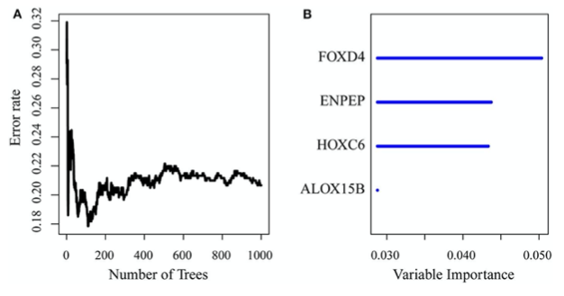

出自https://www.frontiersin.org/articles/10.3389/fonc.2020.00595/full fromhttps://www.frontiersin.org/articles/10.3389/fonc.2020.00595/full

FIGURE 5 | (A) Error rate for the data as a function of the classification tree; (B) out-of-bag importance values for the predictors.

# 应用场景

# Application Scenarios

使用随机森林对生存数据降维，根据变量重要性排序并筛选基因组成prognostic signature The survival data was dimensionally reduced using random forest, and the prognostic signature of genetic composition was sorted and screened according to the importance of variables

# 环境设置

# Environment Setup

```r
source("install_dependencies.R")
```

```
## Starting R package installation...
## ===========================================
##
## Installing CRAN packages...
## Package already installed: randomForestSRC
## Package already installed: survival
##
## Installing randomSurvivalForest from source...
## Installing package from source: https://cran.r-project.org/src/contrib/Archive/randomSurvivalForest/randomSurvivalForest_3.6.4.tar.gz
```

```
##
## ===========================================
## Package installation completed!
## You can now run your R scripts in this directory.
```

```r
library(survival)
library(randomForestSRC)
library(randomSurvivalForest)
Sys.setenv(LANGUAGE = "en") #显示英文报错信息  # Display an English error message
options(stringsAsFactors = FALSE) #禁止chr转成factor  # prohibit chr from being converted to factor
```

自定义函数 Custom function

```r
# 显示进程
# Show Process
display.progress = function (index, totalN, breakN=20) {
  if ( index %% ceiling(totalN/breakN)  ==0  ) {
    cat(paste(round(index*100/totalN), "% ", sep=""))
  }
}

# 相对重要性（relative importance）；其实就是把重要性划分到0-1区间内
# relative importance; In fact, it is to divide the importance into the range of 0 to 1
# range01 <- function(x){(x-min(x))/(max(x)-min(x))}
```

# 输入文件

# Input File

easy_input_expr.csv，表达矩阵。 easy_input_expr.csv, expressing matrix.

easy_input_cli.csv，临床信息。这两个文件跟FigureYa128Prognostic的一样，可以对比感受一下筛选效果。 easy_input_cli.csv, clinical information. These two documents are the same as those in FigureYa128Prognostic. You can compare them to get a sense of the screening effect.

```r
# 加载数据（来自FigureYa128Prognostic）
# Loading Data (from FigureYa128Prognostic)
exp <- read.csv("easy_input_expr.csv",header = T,row.names = 1,check.names = F,stringsAsFactors = F)
cli <- read.csv("easy_input_cli.csv",header = T,row.names = 1,check.names = F,stringsAsFactors = F)

# 提取既有表达数据又有临床数据的样本
# Extract samples that have both expressive data and clinical data
com_sam <- intersect(colnames(exp),rownames(cli))
exp <- exp[,com_sam]
cli <- cli[com_sam,]

# 去除无表达的基因并log变换
# Remove unexpressed genes and perform log transformation
exp <- exp[rowSums(exp) > 0,]
exp <- log2(exp + 1)
```

# 单变量cox模型筛选预后基因

# Univariate cox model for screening prognostic genes

理论上表达谱会优先进行一些筛选，如原文使用单变量cox模型筛选预后基因(P < 0.01)。 Theoretically, the expression profile would prioritize some screenings, such as the original text using a univariate cox model to screen prognostic genes (P < 0.01).

这步运行时间稍长，我这里运行不到10min。 This step takes a bit longer to run. I run it for less than 10 minutes here.

```r
# 过滤出与OS有关的基因
# Filter out genes related to OS
cox.pcutoff <- 0.01 # 例文阈值设为0.01  # The threshold in the example is set to 0.01
Coxoutput.OS <- NULL
for (i in 1:nrow(exp)) {
  display.progress(index = i,totalN = nrow(exp)) # 显示进度   # shows progress

  # 产生临时变量存储生存以及变量表达值
  # Generate temporary variables to store survival and variable expression values
  tmp <- data.frame(gene = as.numeric(exp[i,]),
                    OS.time = cli[,"OS.time"],
                    OS = cli[,"OS"],
                    stringsAsFactors = F)

  # 单变量cox比例风险模型
  # Univariate cox proportional hazards model
  cox <- coxph(Surv(OS.time, OS) ~ gene, data = tmp)
  coxSummary = summary(cox)

  # 生成cox结果数据框，包括基因名，风险比，z值，waldtest p值，以及HR置信区间
  # Generate cox result data frames, including gene names, hazard ratios, Z-values, waldtest P-values, and HR confidence intervals
  Coxoutput.OS=rbind.data.frame(Coxoutput.OS,data.frame(gene=rownames(exp)[i],
                                                        HR=as.numeric(coxSummary$coefficients[,"exp(coef)"]),
                                                        z=as.numeric(coxSummary$coefficients[,"z"]),
                                                        pvalue=as.numeric(coxSummary$coefficients[,"Pr(>|z|)"]),
                                                        lower=as.numeric(coxSummary$conf.int[,3]),
                                                        upper=as.numeric(coxSummary$conf.int[,4]),
                                                        stringsAsFactors = F),
                                stringsAsFactors = F)
}
```

```
## 5%
```

```
## 10%
```

[output not shown]

```
## 15%
```

[output not shown]

[output cut: 9 more lines]

[output not shown]

```
## 20%
```

[output not shown]

[output cut: 55 more lines]

[output not shown]

```
## 25%
```

[output not shown]

[output cut: 241 more lines]

[output not shown]

```
## 30%
```

[output not shown]

[output cut: 105 more lines]

[output not shown]

[output not shown]

[output cut: 537 more lines]

[output not shown]

```
## 35%
```

[output not shown]

[output cut: 985 more lines]

[output not shown]

```
## 40%
```

[output not shown]

[output cut: 113 more lines]

[output not shown]

[output not shown]

[output cut: 573 more lines]

[output not shown]

```
## 45%
```

[output not shown]

[output not shown]

[output cut: 109 more lines]

[output not shown]

[output not shown]

[output cut: 153 more lines]

[output not shown]

[output not shown]

[output cut: 217 more lines]

[output not shown]

```
## 50%
```

[output not shown]

[output cut: 265 more lines]

[output not shown]

[output not shown]

[output cut: 327 more lines]

[output not shown]

```
## 55%
```

[output not shown]

[output cut: 133 more lines]

[output not shown]

[output not shown]

[output cut: 43 more lines]

[output not shown]

[output not shown]

[output cut: 339 more lines]

[output not shown]

```
## 60%
```

[output not shown]

[output cut: 69 more lines]

[output not shown]

[output not shown]

[output cut: 559 more lines]

[output not shown]

[output not shown]

```
## 65%
```

[output not shown]

[output cut: 327 more lines]

[output not shown]

[output not shown]

[output cut: 121 more lines]

[output not shown]

[output not shown]

[output not shown]

[output cut: 111 more lines]

[output not shown]

```
## 70%
```

[output not shown]

[output cut: 983 more lines]

[output not shown]

[output not shown]

[output cut: 159 more lines]

[output not shown]

```
## 75%
```

[output not shown]

[output cut: 419 more lines]

[output not shown]

[output not shown]

[output cut: 63 more lines]

[output not shown]

[output not shown]

[output cut: 189 more lines]

[output not shown]

```
## 80%
```

[output not shown]

[output cut: 589 more lines]

[output not shown]

```
## 85%
```

[output not shown]

[output cut: 45 more lines]

[output not shown]

[output not shown]

[output cut: 421 more lines]

[output not shown]

[output not shown]

[output cut: 119 more lines]

[output not shown]

```
## 90%
```

[output not shown]

[output cut: 111 more lines]

[output not shown]

[output not shown]

[output cut: 505 more lines]

[output not shown]

```
## 95%
```

[output not shown]

[output cut: 591 more lines]

[output not shown]

[output not shown]

[output cut: 195 more lines]

[output not shown]

```r
head(Coxoutput.OS)
```

```
##       gene        HR          z    pvalue     lower    upper
## 1   TSPAN6 1.1675062  1.0443178 0.2963384 0.8730275 1.561315
## 2     TNMD 1.0320474  0.2759680 0.7825727 0.8249027 1.291209
## 3     DPM1 0.9264529 -0.4112470 0.6808914 0.6437340 1.333338
## 4    SCYL3 0.9424900 -0.1831085 0.8547129 0.4999644 1.776701
## 5 C1ORF112 0.8880511 -0.4227189 0.6725004 0.5121145 1.539958
## 6      FGR 1.0286699  0.2368115 0.8128031 0.8140924 1.299806
```

```r
write.csv(Coxoutput.OS,"univariate cox regression for gene filtering.csv",row.names = F,quote = F)
```

# 随机森林进一步降维

# The random forest further reduces dimensions

```r
gene.sel <- Coxoutput.OS[which(Coxoutput.OS$pvalue < cox.pcutoff),"gene"]
tmp <- exp[gene.sel,]; rownames(tmp) <- gsub("-","_",rownames(tmp)) # 防止出现“-”导致程序报错 # Prevent the occurrence of "-" from causing program errors
dt.rf <- cbind.data.frame(cli,t(tmp))

ntree <- 1000
surv.rf <- randomSurvivalForest::rsf(Surv(OS.time, OS) ~ .,
                                     data = dt.rf,
                                     ntree = ntree,
                                     seed = 12345678)
```

# 开始画图

# Start drawing

## 用包里自带的函数直接出图

## Use the built-in functions in the package to directly generate the graph

```r
pdf("error rate and importance derived from package.pdf",width = 12,height = 12)
randomSurvivalForest::plot.error(surv.rf)
```

```
##
##                Importance   Relative Imp
## KRT15              0.0176         1.0000
## DNAJB2             0.0069         0.3929
## AL031777.1         0.0064         0.3643
## IGFBP3             0.0055         0.3143
## NCLP1              0.0050         0.2857
## LANCL3             0.0049         0.2786
## URGCP_MRPS24       0.0043         0.2429
## AC034213.1         0.0038         0.2143
## GJA3               0.0033         0.1857
## MIR574             0.0031         0.1786
## FOXH1              0.0031         0.1786
## RABGGTA            0.0029         0.1643
## AC010973.2         0.0026         0.1500
## AC128689.1         0.0023         0.1286
## LINC00261          0.0021         0.1214
## ELK2BP             0.0021         0.1214
## MIR103A2           0.0021         0.1214
## AL158847.1         0.0019         0.1071
## LINC01507          0.0019         0.1071
## EVA1B              0.0019         0.1071
## GRN                0.0019         0.1071
## KHDC1L             0.0018         0.1000
## GABRD              0.0018         0.1000
## DLX1               0.0018         0.1000
## NPM1P25            0.0016         0.0929
## TIMP1              0.0016         0.0929
## LINC02303          0.0015         0.0857
## AC116614.1         0.0015         0.0857
## NARF               0.0015         0.0857
## MIR210             0.0014         0.0786
## NECAB3             0.0014         0.0786
## AC093668.1         0.0013         0.0714
## AC113367.2         0.0013         0.0714
## NMRAL2P            0.0013         0.0714
## CCKBR              0.0013         0.0714
## PPARGC1A           0.0013         0.0714
## CRYBA4             0.0011         0.0643
## JAG2               0.0011         0.0643
```

[output cut: 47 more lines]

```
## MAN1B1_AS1         0.0004         0.0214
## AC009097.4         0.0004         0.0214
## LINC01989          0.0004         0.0214
## AC126696.3         0.0004         0.0214
## AL133367.1         0.0004         0.0214
## AC017100.1         0.0004         0.0214
## PGAM5P1            0.0004         0.0214
## AC004951.3         0.0004         0.0214
## LINC01143          0.0004         0.0214
## LINC00899          0.0004         0.0214
## ZBTB46_AS1         0.0004         0.0214
## TMEM213            0.0004         0.0214
## CCDC151            0.0004         0.0214
## SEPT5              0.0004         0.0214
## FASTK              0.0004         0.0214
```

```r
dev.off()
```

## 自定义画图

## Custom drawing

```r
# 图1. 错误率
# Figure 1. Error Rate
err.rate <- surv.rf$err.rate
pdf("error rate.pdf",width = 5,height = 5)
par(bty = "o", mgp = c(1.5,.33,0), mar = c(3,4,1,2),las = 1, tcl = -.25)
plot(1:ntree,err.rate,
     xlab = "Number of Trees",
     ylab = "",
     type = "l",
     las = 1,
     cex = 1.5)
mtext("Error Rate",side = 2,line = 2.5,las = 3)
invisible(dev.off())

# 图2. 重要性
# Figure 2. Importance
raw.imp <- surv.rf$importance; names(raw.imp) <- gsub("_","-",names(raw.imp)) # 将基因名的“_”还原为“-” # will gene name "_" to "-"
rel.imp <- raw.imp/max(abs(raw.imp)) # calculate relative importance

# 输出重要性矩阵
# Output the importance matrix
imp.res <- data.frame(gene = names(raw.imp),
                      raw.importance = raw.imp,
                      rel.importance = rel.imp,
                      stringsAsFactors = F)
write.csv(imp.res[order(imp.res$rel.importance,decreasing = T),],"importance result.csv",row.names = F,quote = F)

# 筛选后画图
# Draw a picture after filtering
imp.cutoff <- 0.2 # 原文的重要性阈值为0.65  # The importance threshold of the original text is 0.65
rel.imp.sel <- rel.imp[rel.imp > imp.cutoff] # 取出大于阈值的变量  # Retrieve variables greater than the threshold
rel.imp.sel <- sort(rel.imp.sel) # 根据重要性排序  # Sort by importance
xrange <- range(pretty(range(rel.imp.sel))) # 根据重要性区间确定x轴范围  # Determine the X-axis range based on the importance interval
yrange <- c(1,length(rel.imp.sel))  # 根据重要变量个数确定y轴范围  # Determine the Y-axis range based on the number of important variables

pdf("relative importance.pdf",width = 5,height = 5)
par(bty = "o", mgp = c(1.5,.33,0), mar = c(3,6,1,2),las = 1, tcl = -.25)
plot(NULL,NULL,
     xlim = xrange,
     ylim = yrange,
     xlab = "Variable Relative Importance",
     ylab = "",
     yaxt = "n",
     las = 1)
axis(side = 2,at = 1:length(rel.imp.sel),names(rel.imp.sel)) # 补齐y轴  # Complete the Y-axis
for (i in 1:length(rel.imp.sel)) { # 循环添加线 # loop to add lines
  lines(c(xrange[1],rel.imp.sel[i]),
        c(i,i),
        lwd = 2.5,
        col = "steelblue") # 颜色可修改   # Color can be modified
}
invisible(dev.off())
```